# PHREEQC Geochemical Modeling: Speciation, Saturation Indices, Geothermometry, and Mixing

Overarching reference for the Steamboat Hills PHREEQC workstream

Published

September 26, 2026

## 1 Purpose and scope

This notebook is the **living scientific reference** for PHREEQC geochemical modeling at Steamboat Hills — it documents *why* each analysis is done, *what* the underlying chemistry/thermodynamics are, and *where* the code that implements it lives (`scripts/phreeqc/`), and it is intended to stay the entry point for this workstream as more chemistry (real Cl end-members overlapping the conductivity logger deployment, alkalinity titrations, well-log identities) accumulates. It complements, but does not replace, the individual R scripts; this document narrates and runs representative pieces of them so the reasoning and the code stay in sync — following the same convention as `01_conductivity_temporal_structure.qmd` for the Cl-sampling-frequency workstream.

Sections below run in dependency order:

**Warning**

As of this writing, real two-end-member mixing and inverse modeling (Section 7) cannot yet be run on real Steamboat samples: the only Cl/isotope field samples collected so far (2026-05-01) predate the conductivity logger deployment (2026-07-15) by roughly 2.5 months, and the downstream/outflow proxy site (`SBGG`) has no chemistry at all yet. Section 7 therefore runs against synthetic self-test data, clearly labeled as such. Sections 3–6 are real and current as of 2026-09-06.

## 2 Scientific motivation

Three questions this project needs answered, in increasing order of how much real data they currently have behind them:

1. **What is the current chemical/thermal state of each sampled water, and is it internally consistent?** — PHREEQC’s aqueous speciation and charge-balance calculation answer this directly: given measured concentrations, pH, and temperature, what species (free ions, ion pairs, complexes) is the dissolved mass actually distributed across, and does the analysis close electrically within an acceptable tolerance? A poor charge balance is a red flag for the *analysis*, not the water.
2. **Is a thermal water in equilibrium with the minerals it’s discharging through, and what does that imply about scaling risk and reservoir temperature?** — Saturation indices ($SI = \log_{10}(IAP/K_{sp})$, zero at equilibrium, positive supersaturated/scaling-prone, negative undersaturated) for calcite, quartz, and related phases answer this. Silica geothermometry in particular is the classic tool for estimating deep reservoir temperature from a *cooled, discharged* fluid, because silica dissolution/precipitation kinetics are slow enough that a discharge sample can retain a partial memory of higher-temperature equilibrium at depth.
3. **Where is the discharge chemistry coming from — how much is deep thermal upflow versus meteoric dilution, and does any mineral reaction happen along the way?** — This is the mixing/inverse-modeling question this thesis’s Cl-discharge framing (`01_conductivity_temporal_structure.qmd`) is ultimately building toward: PHREEQC’s `MIX` and `INVERSE_MODELING` keywords test two-end-member mixing hypotheses directly, with or without an accompanying mineral reaction. This is the piece still waiting on real overlapping chemistry (see the warning above).

## 3 Architecture

```
flowchart LR
    A[Lab_Analyses + Field_Measurements + Isotope_Analyses] --> B["build_phreeqc_solutions(con)<br/>08_build_phreeqc_tables.R"]
    B --> C[(PHREEQC_Solutions)]
    C --> D["run_phreeqc_pipeline(con)<br/>09_run_phreeqc.R"]
    D -->|"system2()"| E[[PHREEQC 3 executable]]
    E --> D
    D --> F[(PHREEQC_Results)]
    D --> G[(PHREEQC_Run_Failures)]
    C --> H["run_phreeqc_temp_sweep(con)<br/>09_run_phreeqc.R"]
    H --> I[(PHREEQC_Temp_Sweep)]
    C --> J["run_mixing_fraction_analysis() /<br/>run_phreeqc_mixing()<br/>10_run_phreeqc_mixing.R"]
    C --> K["run_phreeqc_inverse()<br/>11_run_phreeqc_inverse.R"]
    C --> L["run_phreeqc_gas_phase()<br/>12_run_phreeqc_gas_phase.R"]
    F --> M["interpret_phreeqc_results()<br/>automated human-readable text"]
```

| Script | Role |
| --- | --- |
| `scripts/phreeqc/utils_phreeqc.R` | SOLUTION-block generation, `system2()` execution of the standalone PHREEQC 3 executable, SELECTED_OUTPUT parsing, the 6-database thermodynamic registry with auto-recommendation, fluid-type classificat… |
| `scripts/phreeqc/08_build_phreeqc_tables.R` | `build_phreeqc_solutions(con)`, `get_phreeqc_eligible(con)` |
| `scripts/phreeqc/09_run_phreeqc.R` | `run_phreeqc_pipeline()`, `run_phreeqc_multi()`, `run_phreeqc_temp_sweep()`, `calculate_activity_geothermometers()` |
| `scripts/phreeqc/10_run_phreeqc_mixing.R` | Two-end-member conservative mixing fractions + PHREEQC `MIX` blocks |
| `scripts/phreeqc/11_run_phreeqc_inverse.R` | PHREEQC `INVERSE_MODELING` (mixing + mineral mass transfer) |
| `scripts/phreeqc/12_run_phreeqc_gas_phase.R` | PHREEQC `GAS_PHASE` (CO2/H2S degassing equilibria) |
| `scripts/phreeqc/run_phreeqc_analysis.R` | Single entry point sequencing all five modes |
| `database/schema/08_phreeqc_schema.R` | `PHREEQC_Solutions`, `PHREEQC_Results`, `PHREEQC_Temp_Sweep`, `PHREEQC_Run_Failures`, and the mixing/inverse/gas-phase table families |

PHREEQC itself is an external executable (USGS PHREEQC 3), not an R package — this project shells out to it via `system2()` rather than using an R binding, matching the pattern of the IGNIS project this workstream was ported from. `PHREEQC_EXE`/`PHREEQC_DB` environment variables override the default search path (`C:/Program Files/USGS/phreeqc/...`).

Database selection is automatic by default (`phreeqc_db = "auto"`): temperatures above 100°C route to the LLNL database (validated high-temperature thermodynamic data to 300°C, standard for geothermal work), high-TDS waters route to Pitzer or SIT, and everything else uses the general-purpose default `phreeqc.dat`. If a batch fails to converge, the pipeline automatically retries with fallback databases, then retries each sample individually — a single problem sample never silently drops every other sample in its batch. Convergence failures that persist across every database tried are logged to `PHREEQC_Run_Failures`, not silently dropped.

```r
library(DBI)
library(RSQLite)
library(dplyr)
library(ggplot2)

# Several scripts/phreeqc/*.R functions (build_phreeqc_solutions() in
# particular, via database/schema/lab_analyte_map.R) source() other project
# files using paths relative to the project root, not this notebook's own
# directory -- Quarto's project-level execute-dir default renders .qmd files
# with their own directory (notebooks/) as the working directory, which
# breaks those internal source() calls. A plain setwd() here isn't enough:
# knitr's in_dir() wraps every chunk and restores the working directory
# in between them, so the change would silently revert before the next
# chunk runs -- opts_knit$set(root.dir = ...) is knitr's own supported way
# to persist a working-directory override across all chunks, matching
# scripts/run_pipeline.R's own root-relative-paths convention.
if (basename(getwd()) == "notebooks") {
  knitr::opts_knit$set(root.dir = normalizePath(".."))
  setwd("..")
}

con <- dbConnect(SQLite(), file.path("database", "geochem_operational.sqlite"))
dbExecute(con, "PRAGMA foreign_keys = ON;")
```

```
[1] 0
```

```r
for (f in c("utils_phreeqc.R", "08_build_phreeqc_tables.R", "09_run_phreeqc.R",
            "10_run_phreeqc_mixing.R", "11_run_phreeqc_inverse.R",
            "12_run_phreeqc_gas_phase.R", "13_gas_geothermometry.R",
            "14_gas_mixing.R", "run_phreeqc_analysis.R")) {
  source(file.path("scripts", "phreeqc", f))
}

phreeqc_available <- tryCatch({ check_phreeqc(); TRUE }, error = function(e) FALSE)
```

`phreeqc_available` is TRUE on the machine this notebook was last rendered on — every live PHREEQC execution below is skipped gracefully (not silently faked) if the executable isn’t found.

## 4 Building `PHREEQC_Solutions`

`build_phreeqc_solutions(con)` derives one row per sample from `Lab_Analyses`, `Field_Measurements`, and `Isotope_Analyses` — temperature, pH, and each major/minor ion, plus a real charge balance computed from `lab_analyte_map.R`’s per-analyte charge and molar mass (not a hardcoded, partial equivalent-weight table). A sample is *eligible* for a full PHREEQC run if it has temperature, pH, Na, and Cl at minimum; everything else is *rejected* with a specific, human-readable reason via `get_phreeqc_eligible()` — never silently dropped.

```r
sol <- build_phreeqc_solutions(con)
```

```
---- Building PHREEQC_Solutions ----
```

```
PHREEQC_Solutions built: 1472 rows (312 complete, 1160 incomplete).
```

```r
eligibility <- get_phreeqc_eligible(con)
cat(sprintf("PHREEQC_Solutions: %d rows total, %d eligible for a full run, %d rejected\n",
            nrow(sol), nrow(eligibility$eligible), nrow(eligibility$rejected)))
```

```
PHREEQC_Solutions: 1472 rows total, 312 eligible for a full run, 1160 rejected
```

```r
loc_info <- dbGetQuery(con, "
  SELECT s.sample_id, s.data_source, l.name AS location_name, l.site_type
  FROM Samples s JOIN Locations l ON s.location_id = l.location_id
")
sol |>
  left_join(loc_info, by = "sample_id") |>
  count(data_source, site_type, completeness_flag) |>
  arrange(data_source, site_type)
```

```
# A tibble: 34 × 4
   data_source site_type       completeness_flag     n
   <chr>       <chr>           <chr>             <int>
 1 FIELD       creek           incomplete            3
 2 FIELD       fumarole        complete              1
 3 FIELD       fumarole        incomplete            1
 4 FIELD       seep            complete              1
 5 FIELD       seep            incomplete           32
 6 FIELD       spring          complete              2
 7 FIELD       spring          incomplete           10
 8 FIELD       steaming ground incomplete           13
 9 FIELD       transect        complete              2
10 FIELD       well            complete              2
# ℹ 24 more rows
```

The first working version of this pipeline found only 8 eligible samples database-wide — all from `FIELD` (springs/wells/fumarole/transect). NDEP’s ~755 background samples and ~10 NDEP PRR wells all looked like they had zero pH/temperature data. Investigating why (because the user specifically asked to run this on existing NDEP data) surfaced three real ingest bugs, not a genuine data gap:

1. **NDEP’s pH and temperature are stored in `Lab_Analyses`, not `Field_Measurements`** — `build_phreeqc_solutions()` originally only checked the latter. Fixed to pull from both, preferring `Field_Measurements` when both exist.
2. **NDEP’s minor/trace analytes are stored in mixed units** (the same analyte, e.g. `SiO2`/`As`/`B`/`Fe`/`Li`/`Mn`, appears with both `ug/L` and `mg/L` rows for different samples) with no ingest-time normalization — previously averaged naively, a ~1000x risk for whichever rows were “wrong” relative to others in the average. Fixed to convert every row to mg/L, per its own `units` column, before any aggregation.
3. **NDEP’s authoritative alkalinity parameter, “Total Alkalinity as CaCO3”, was never ingested at all.** `ndep_analyte_map.R` instead mapped two *unit-convention duplicates* of the same measurement (“HCO3 as CaCO3”/“HCO3 as HCO3”, confirmed via the raw source file to be the exact same 647 events, ratio consistently 0.82 — matching the true CaCO3/HCO3 equivalent-weight ratio) to a single `HCO3` analyte code, with no conversion factor. Added the missing “Total Alkalinity” mapping (with the correct CaCO3 -> HCO3 mass conversion, $61.017/50.05 = 1.2189$), and remapped the duplicate-convention rows to distinct, explicitly-excluded codes so they can never collide again.

A fourth, separate bug in `lab_analyte_map.R` — the `Alkalinity` row had `charge = 0, molar_mass = NA`, silently excluding it from every charge-balance calculation even after real data existed — meant the fix above didn’t move the charge-balance numbers at all until this was also corrected (see the next section).

**A fifth, independent instance of the same class of bug** was found in `ingest_lab.R` (FIELD’s own lab-report parser): `normalize_lab_wide()` ran raw CSV headers through `make.names()` for R-safe column names, which turns `"Alkalinity Total"` into `"Alkalinity.Total"` (space $\to$ dot) — and then used that *mangled* name as the join key against `lab_analyte_map$raw_name` (`"Alkalinity Total"`, with a space), guaranteed to never match. Every FIELD sample’s Alkalinity (and NO3, the only other multi-word raw name) had been silently dropped since this pipeline’s very first field-lab ingest, not missing due to a genuine sampling gap as earlier sessions assumed. Fixed to preserve the original header text as the actual join key.

See `AGENTS.md` (Sessions 15–16) for the full narrative, including the raw per-row evidence for each fix.

## 5 Charge-balance QC

```r
complete_sol <- sol |>
  left_join(loc_info, by = "sample_id") |>
  filter(completeness_flag == "complete", !is.na(charge_balance))

complete_sol |>
  mutate(qc_flag = ifelse(abs(charge_balance) > 5, "FLAG (>5%)", "OK (<=5%)")) |>
  count(data_source, qc_flag)
```

```
# A tibble: 6 × 3
  data_source          qc_flag        n
  <chr>                <chr>      <int>
1 FIELD                OK (<=5%)      8
2 Mariner & Janik 1995 FLAG (>5%)     4
3 Mariner & Janik 1995 OK (<=5%)     70
4 NDEP                 FLAG (>5%)    61
5 NDEP                 OK (<=5%)    164
6 Sorey & Colvard 1992 OK (<=5%)      5
```

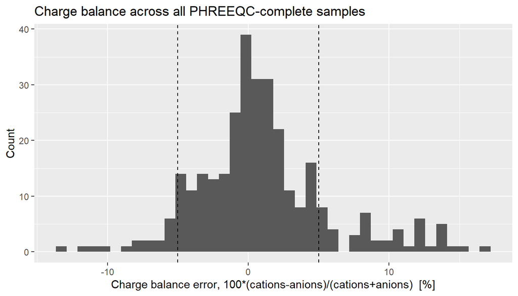

```r
ggplot(complete_sol, aes(x = charge_balance)) +
  geom_histogram(bins = 40) +
  geom_vline(xintercept = c(-5, 5), linetype = "dashed") +
  labs(x = "Charge balance error, 100*(cations-anions)/(cations+anions)  [%]",
       y = "Count", title = "Charge balance across all PHREEQC-complete samples")
```

The dashed lines mark the conventional ±5% acceptability threshold. Before the alkalinity fixes above, essentially every complete sample failed this check with a median imbalance around 60% — a pure artifact of excluding alkalinity (typically the dominant anion in these near-neutral waters) from the anion sum entirely, not a real geochemical signal. After the fixes, the median imbalance for NDEP’s complete samples is close to zero and most pass the standard threshold; FIELD’s own samples are now fully alkalinity-complete too (see the callout above).

## 6 Speciation and saturation indices

```r
speciation_result <- run_phreeqc_pipeline(con)
```

```
PHREEQC found: C:/Program Files/USGS/phreeqc/bin/Release/phreeqc.exe
```

```
Database:      C:/Program Files/USGS/phreeqc/database/phreeqc.dat
```

```
--- PHREEQC Eligibility (all site types) ---
```

```
  Eligible:  312 samples
```

```
  Rejected:  1160 samples
```

```
  Rejection details:
```

```
    1 (Thomas Creek @ North Timberline Drive &[STBT03Thomas-3]): missing Na
```

```
    2 (Thomas Creek @ North Timberline Drive &[STBT03Thomas-3]): missing Na
```

```
    3 (Thomas Creek @ North Timberline Drive &[STBT03Thomas-3]): missing Na
```

```
    4 (Thomas Creek @ North Timberline Drive &[STBT03Thomas-3]): missing Na
```

```
    5 (Thomas Creek @ North Timberline Drive &[STBT03Thomas-3]): missing Na
```

```
    6 (Thomas Creek @ North Timberline Drive &[STBT03Thomas-3]): missing Na
```

```
    7 (Thomas Creek @ North Timberline Drive &[STBT03Thomas-3]): missing temperature; missing Na
```

```
    8 (Thomas Creek @ North Timberline Drive &[STBT03Thomas-3]): missing Na
```

```
    9 (Thomas Creek @ North Timberline Drive &[STBT03Thomas-3]): missing pH; missing Na
```

```
    10 (Thomas Creek @ North Timberline Drive &[STBT03Thomas-3]): missing pH; missing Na
```

```
    11 (Thomas Creek @ North Timberline Drive &[STBT03Thomas-3]): missing pH; missing Na
```

```
    12 (Thomas Creek @ North Timberline Drive &[STBT03Thomas-3]): missing pH; missing Na
```

```
    13 (Thomas Creek @ North Timberline Drive &[STBT03Thomas-3]): missing pH; missing Na
```

```
    14 (Thomas Creek @ North Timberline Drive &[STBT03Thomas-3]): missing pH; missing Na
```

```
    15 (Thomas Creek @ North Timberline Drive &[STBT03Thomas-3]): missing pH; missing Na
```

```
    16 (Thomas Creek @ North Timberline Drive &[STBT03Thomas-3]): missing pH; missing Na
```

```
    17 (Thomas Creek @ North Timberline Drive &[STBT03Thomas-3]): missing pH; missing Na
```

```
    18 (Thomas Creek @ North Timberline Drive &[STBT03Thomas-3]): missing pH; missing Na
```

```
    19 (Thomas Creek @ North Timberline Drive &[STBT03Thomas-3]): missing pH; missing Na
```

```
    20 (Thomas Creek @ North Timberline Drive &[STBT03Thomas-3]): missing pH; missing Na
```

```
    ... and 1140 more
```

```
  Database recommendation: LLNL (thermo.com.V8.R6.230)
```

```
  Reason: Maximum temperature 221C exceeds 100C. LLNL database has validated high-T thermodynamic data up to 300C.
```

```
  Alternatives: phreeqc
```

```
=== Processing site_type: creek (227 samples) [LLNL (thermo.com.V8.R6.230)] ===
```

```
Wrote PHREEQC input: phreeqc/runs/creek/phreeqc_inputs/creek_llnl.pqi (227 solutions)
```

```
Running PHREEQC...
```

```
  Input:    C:\Projects\STEAMB~1\STEAMB~3\phreeqc\runs\creek\PHREEQ~1\CREEK_~1.PQI
```

```
  Output:   C:\Projects\STEAMB~1\STEAMB~3\phreeqc\runs\creek\PHREEQ~2/creek_llnl.pqo
```

```
  Database: C:\PROGRA~1\USGS\phreeqc\database\llnl.dat
```

```
  Retrying creek with fallback: SIT (Specific Ion Interaction Theory)
```

```
Wrote PHREEQC input: phreeqc/runs/creek/phreeqc_inputs/creek_sit.pqi (227 solutions)
```

```
Running PHREEQC...
```

```
  Input:    C:\Projects\STEAMB~1\STEAMB~3\phreeqc\runs\creek\PHREEQ~1\CREEK_~2.PQI
```

```
  Output:   C:\Projects\STEAMB~1\STEAMB~3\phreeqc\runs\creek\PHREEQ~2/creek_sit.pqo
```

```
  Database: C:\PROGRA~1\USGS\phreeqc\database\sit.dat
```

```
PHREEQC completed successfully.
```

[output not shown]

```
  Retrying well with fallback: SIT (Specific Ion Interaction Theory)
Wrote PHREEQC input: phreeqc/runs/well/phreeqc_inputs/well_sit.pqi (73 solutions)
Running PHREEQC...
  Input:    C:\Projects\STEAMB~1\STEAMB~3\phreeqc\runs\well\PHREEQ~1\well_sit.pqi
  Output:   C:\Projects\STEAMB~1\STEAMB~3\phreeqc\runs\well\PHREEQ~2/well_sit.pqo
  Database: C:\PROGRA~1\USGS\phreeqc\database\sit.dat
```

```
  Retrying well with fallback: Pitzer
Wrote PHREEQC input: phreeqc/runs/well/phreeqc_inputs/well_pitzer.pqi (73 solutions)
Running PHREEQC...
  Input:    C:\Projects\STEAMB~1\STEAMB~3\phreeqc\runs\well\PHREEQ~1\WELL_P~1.PQI
  Output:   C:\Projects\STEAMB~1\STEAMB~3\phreeqc\runs\well\PHREEQ~2/well_pitzer.pqo
  Database: C:\PROGRA~1\USGS\phreeqc\database\pitzer.dat
```

[output not shown]

```
Wrote PHREEQC input: phreeqc/runs/well/phreeqc_inputs/837_sit.pqi (1 solutions)
Running PHREEQC...
  Input:    C:\Projects\STEAMB~1\STEAMB~3\phreeqc\runs\well\PHREEQ~1\837_sit.pqi
  Output:   C:\Projects\STEAMB~1\STEAMB~3\phreeqc\runs\well\PHREEQ~2/837_sit.pqo
  Database: C:\PROGRA~1\USGS\phreeqc\database\sit.dat
```

```
Wrote PHREEQC input: phreeqc/runs/well/phreeqc_inputs/837_pitzer.pqi (1 solutions)
Running PHREEQC...
  Input:    C:\Projects\STEAMB~1\STEAMB~3\phreeqc\runs\well\PHREEQ~1\837_PI~1.PQI
  Output:   C:\Projects\STEAMB~1\STEAMB~3\phreeqc\runs\well\PHREEQ~2/837_pitzer.pqo
  Database: C:\PROGRA~1\USGS\phreeqc\database\pitzer.dat
```

```
Wrote PHREEQC input: phreeqc/runs/well/phreeqc_inputs/838_llnl.pqi (1 solutions)
Running PHREEQC...
  Input:    C:\Projects\STEAMB~1\STEAMB~3\phreeqc\runs\well\PHREEQ~1\838_llnl.pqi
  Output:   C:\Projects\STEAMB~1\STEAMB~3\phreeqc\runs\well\PHREEQ~2/838_llnl.pqo
  Database: C:\PROGRA~1\USGS\phreeqc\database\llnl.dat
```

```
Wrote PHREEQC input: phreeqc/runs/well/phreeqc_inputs/838_sit.pqi (1 solutions)
Running PHREEQC...
  Input:    C:\Projects\STEAMB~1\STEAMB~3\phreeqc\runs\well\PHREEQ~1\838_sit.pqi
  Output:   C:\Projects\STEAMB~1\STEAMB~3\phreeqc\runs\well\PHREEQ~2/838_sit.pqo
  Database: C:\PROGRA~1\USGS\phreeqc\database\sit.dat
```

```
Wrote PHREEQC input: phreeqc/runs/well/phreeqc_inputs/838_pitzer.pqi (1 solutions)
Running PHREEQC...
  Input:    C:\Projects\STEAMB~1\STEAMB~3\phreeqc\runs\well\PHREEQ~1\838_PI~1.PQI
  Output:   C:\Projects\STEAMB~1\STEAMB~3\phreeqc\runs\well\PHREEQ~2/838_pitzer.pqo
  Database: C:\PROGRA~1\USGS\phreeqc\database\pitzer.dat
```

[output not shown]

[output cut: 13 more lines]

[output not shown]

```
Wrote PHREEQC input: phreeqc/runs/well/phreeqc_inputs/856_sit.pqi (1 solutions)
Running PHREEQC...
  Input:    C:\Projects\STEAMB~1\STEAMB~3\phreeqc\runs\well\PHREEQ~1\856_sit.pqi
  Output:   C:\Projects\STEAMB~1\STEAMB~3\phreeqc\runs\well\PHREEQ~2/856_sit.pqo
  Database: C:\PROGRA~1\USGS\phreeqc\database\sit.dat
```

[output not shown]

```
Wrote PHREEQC input: phreeqc/runs/well/phreeqc_inputs/859_sit.pqi (1 solutions)
Running PHREEQC...
  Input:    C:\Projects\STEAMB~1\STEAMB~3\phreeqc\runs\well\PHREEQ~1\859_sit.pqi
  Output:   C:\Projects\STEAMB~1\STEAMB~3\phreeqc\runs\well\PHREEQ~2/859_sit.pqo
  Database: C:\PROGRA~1\USGS\phreeqc\database\sit.dat
```

[output not shown]

[output cut: 353 more lines]

[output not shown]

```r
si_wide <- dbGetQuery(con, "
  SELECT pr.sample_id, l.name AS location_name, l.site_type, pr.parameter, pr.value, pr.db_file
  FROM PHREEQC_Results pr
  JOIN Samples s ON pr.sample_id = s.sample_id
  JOIN Locations l ON s.location_id = l.location_id
  WHERE pr.parameter LIKE 'SI_%'
") |>
  filter(value > -100) |>
  tidyr::pivot_wider(names_from = parameter, values_from = value,
                      id_cols = c(sample_id, location_name, site_type, db_file))

si_wide |> filter(site_type != "background") |> arrange(sample_id)
```

```
# A tibble: 312 × 14
   sample_id location_name site_type db_file SI_Calcite SI_Aragonite SI_Dolomite
       <int> <chr>         <chr>     <chr>        <dbl>        <dbl>       <dbl>
 1        72 Thomas Creek… creek     sit.dat     -0.802      -0.970       -1.93
 2        75 Thomas Creek… creek     sit.dat     -0.726      -0.894       -1.61
 3        78 Thomas Creek… creek     sit.dat     -0.439      -0.607       -1.03
 4        81 Thomas Creek… creek     sit.dat     -0.725      -0.894       -1.56
 5        86 Thomas Creek… creek     sit.dat      0.102      -0.0669       0.160
 6        88 Thomas Creek… creek     sit.dat     -1.13       -1.29        -2.47
 7        91 Thomas Creek… creek     sit.dat     -0.921      -1.09        -1.85
 8        94 Thomas Creek… creek     sit.dat     -1.25       -1.41        -2.60
 9        96 Thomas Creek… creek     sit.dat     -1.22       -1.39        -2.40
10        98 Thomas Creek… creek     sit.dat     -1.09       -1.26        -1.98
# ℹ 302 more rows
# ℹ 7 more variables: SI_Quartz <dbl>, SI_Chalcedony <dbl>, SI_Gypsum <dbl>,
#   SI_Anhydrite <dbl>, SI_Halite <dbl>, SI_Fluorite <dbl>, SI_SiO2_a_ <dbl>
```

```r
cat(interpret_phreeqc_results(con))
```

**ImportantNa/K geothermometry is only physically meaningful for genuinely thermal samples**

`interpret_phreeqc_results()`’s SI-based read is database-agnostic and correct for every sample it covers. But applying **activity-based Na/K geothermometry** (next section) to NDEP’s ~225 dilute, cold (median ~11°C) background creek/well samples gives geothermometer estimates of 300–390°C — not a real finding, a violation of the method’s core assumption (water-rock equilibrium, which doesn’t hold for shallow, dilute, fast-flowing surface water). Only the 8 real FIELD thermal samples (measured temperature 59–162°C) are appropriate inputs for Na/K geothermometry; this notebook restricts that analysis to them explicitly rather than reporting the background numbers at face value.

## 7 Geothermometry

Two independent geothermometers are computed on the real thermal FIELD samples: **activity-based Na/K** (Giggenbach 1988; Fournier 1979), computed directly from PHREEQC’s speciated ion activities rather than raw concentrations — important because these are moderately saline waters where activity and concentration diverge — and a **multicomponent mineral-equilibration temperature sweep** (Reed & Spycher 1984 approach): run each SOLUTION across a temperature ramp (25–300°C by 25°C) and find where each mineral’s saturation index crosses zero.

```r
thermal_ids <- loc_info |>
  filter(data_source == "FIELD", site_type %in% c("well", "spring", "seep", "fumarole", "transect")) |>
  semi_join(sol |> filter(completeness_flag == "complete"), by = "sample_id") |>
  pull(sample_id)
thermal_ids
```

```
[1] 815 816 818 819 820 821 822 825
```

```r
geo_nak <- calculate_activity_geothermometers(con) |>
  filter(sample_id %in% thermal_ids) |>
  select(sample_id, location_name, T_NaK_gigg_activity, T_NaK_four_activity)
geo_nak
```

```
# A tibble: 8 × 4
  sample_id location_name T_NaK_gigg_activity T_NaK_four_activity
      <int> <chr>                       <dbl>               <dbl>
1       816 SBF_0001                     173.                154.
2       820 SBS_0002                     189.                171.
3       822 SBS_0003                     188.                170.
4       825 SBS_0001                     184.                166.
5       818 SBBV                         197.                179.
6       819 SBRR                         256.                243.
7       815 SBW_0002                     178.                160.
8       821 SBW_0001                     180.                161.
```

```r
sweep_res <- run_phreeqc_temp_sweep(con, sample_ids = thermal_ids,
                                     temp_range = c(25, 300), temp_step = 25,
                                     phreeqc_db = "llnl")
```

```
PHREEQC found: C:/Program Files/USGS/phreeqc/bin/Release/phreeqc.exe
```

```
Database:      C:/Program Files/USGS/phreeqc/database/phreeqc.dat
```

```
--- Temperature Sweep (all site types) ---
```

```
  Eligible samples: 8
```

```
  Temperature range: 25-300°C
```

```
  Step size: 25°C
```

```
  Wrote sweep input: phreeqc/runs/temp_sweep/sweep_llnl_20260926_185325.pqi (8 samples)
```

```
Running PHREEQC...
```

```
  Input:    C:\Projects\STEAMB~1\STEAMB~3\phreeqc\runs\TEMP_S~1\SWF934~1.PQI
```

```
  Output:   C:\Projects\STEAMB~1\STEAMB~3\phreeqc\runs\TEMP_S~1/sweep_llnl_20260926_185325.pqo
```

```
  Database: C:\PROGRA~1\USGS\phreeqc\database\llnl.dat
```

```
PHREEQC completed successfully.
```

```
Stored 2704 temperature sweep rows for 8 samples.
Estimated equilibration temperatures:
815 (Anhydrite): 271°C
816 (Anhydrite): 278°C
816 (Aragonite): 35°C
816 (Chalcedony): 92°C
816 (Quartz): 118°C
818 (Chalcedony): 44°C
818 (Quartz): 61°C
819 (Aragonite): 32°C
819 (Chalcedony): 36°C
819 (Quartz): 52°C
820 (Anhydrite): 209°C
820 (Aragonite): 66°C
820 (Calcite): 43°C
820 (Chalcedony): 96°C
820 (Quartz): 123°C
821 (Anhydrite): 231°C
821 (Chalcedony): 75°C
821 (Quartz): 99°C
822 (Anhydrite): 238°C
822 (Chalcedony): 79°C
```

```r
quartz_chal <- sweep_res$eq_temps |>
  filter(mineral %in% c("Quartz", "Chalcedony")) |>
  select(sample_id, mineral, eq_temperature_C) |>
  tidyr::pivot_wider(names_from = mineral, values_from = eq_temperature_C, names_prefix = "T_")

comparison <- sol |>
  filter(sample_id %in% thermal_ids) |>
  select(sample_id, T_measured = temperature) |>
  left_join(quartz_chal, by = "sample_id") |>
  left_join(geo_nak, by = "sample_id") |>
  mutate(across(where(is.numeric), ~round(., 0)))
comparison
```

```
# A tibble: 8 × 7
  sample_id T_measured T_Chalcedony T_Quartz location_name T_NaK_gigg_activity
      <dbl>      <dbl>        <dbl>    <dbl> <chr>                       <dbl>
1       815        149           NA       NA SBW_0002                      178
2       816        153           92      118 SBF_0001                      173
3       818         75           44       61 SBBV                          197
4       819         59           36       52 SBRR                          256
5       820        162           96      123 SBS_0002                      189
6       821        160           75       99 SBW_0001                      180
7       822        103           79      103 SBS_0003                      188
8       825        118           99      127 SBS_0001                      184
# ℹ 1 more variable: T_NaK_four_activity <dbl>
```

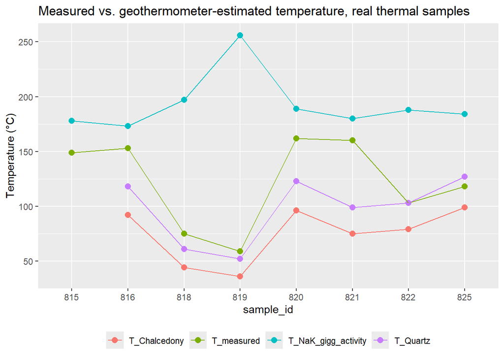

```r
comparison |>
  tidyr::pivot_longer(cols = c(T_measured, T_Quartz, T_Chalcedony, T_NaK_gigg_activity),
                       names_to = "series", values_to = "temperature_C") |>
  ggplot(aes(x = factor(sample_id), y = temperature_C, color = series, group = series)) +
  geom_point(size = 2.5) +
  geom_line(aes(group = series)) +
  labs(x = "sample_id", y = "Temperature (\u00B0C)",
       title = "Measured vs. geothermometer-estimated temperature, real thermal samples",
       color = NULL) +
  theme(legend.position = "bottom")
```

## 8 Mixing, inverse modeling, and gas-phase equilibria

These three modes are built and pass synthetic self-tests, but — per the warning at the top of this notebook — real chemistry doesn’t yet overlap the conductivity logger deployment closely enough to name confident real thermal and meteoric end-members. They are deliberately **not** run automatically by `run_pipeline.R`; each requires the caller to name real `sample_id`s explicitly (never inferred), matching this project’s standing rule against guessing which samples are meaningful end-members.

```r
demo_results <- demo_phreeqc_analysis()
```

```
 PHREEQC modeling self-tests (synthetic)
```

```
---- Mixing model self-test (synthetic end-members) ----
```

```
  Synthetic 50/50 mix: true Cl = 702.5 mg/L, recovered fraction = 0.5000 (expected 0.5) -- PASS
```

```
PHREEQC found: C:/Program Files/USGS/phreeqc/bin/Release/phreeqc.exe
```

```
Database:      C:/Program Files/USGS/phreeqc/database/phreeqc.dat
```

```
Running PHREEQC...
```

```
  Input:    C:\Users\tyler\AppData\Local\Temp\RTMPMB~1\PHREEQ~1\demo.pqi
```

```
  Output:   C:\Users\tyler\AppData\Local\Temp\RTMPMB~1\PHREEQ~1/demo.pqo
```

```
  Database: C:\PROGRA~1\USGS\phreeqc\database\phreeqc.dat
```

```
PHREEQC completed successfully.
```

```
  PHREEQC MIX block executed successfully -- see C:\Users\tyler\AppData\Local\Temp\RtmpMB39aj\phreeqc_mix_demo_bd4411617d7c/demo_selected.tsv for full speciation of the synthetic 50/50 mix.
```

```
---- Inverse model self-test (synthetic end-members) ----
```

```
  INVERSE_MODELING input block generated: PASS (syntax present)
```

```
PHREEQC found: C:/Program Files/USGS/phreeqc/bin/Release/phreeqc.exe
```

```
Database:      C:/Program Files/USGS/phreeqc/database/phreeqc.dat
```

```
Running PHREEQC...
```

```
  Input:    C:\Users\tyler\AppData\Local\Temp\RTMPMB~1\PHREEQ~2\demo.pqi
```

```
  Output:   C:\Users\tyler\AppData\Local\Temp\RTMPMB~1\PHREEQ~2/demo.pqo
```

```
  Database: C:\PROGRA~1\USGS\phreeqc\database\phreeqc.dat
```

```
PHREEQC completed successfully.
```

```
  PHREEQC ran the inverse model to completion (exit code 0, input/-balances syntax accepted) but found 0 feasible mixing+phase solutions for this synthetic scenario. Inspecting C:\Users\tyler\AppData\Local\Temp\RtmpMB39aj\phreeqc_inverse_demo_bd444585234c/demo.pqo directly: this is consistent with a…
```

```
---- Gas phase self-test (synthetic CO2-charged solution) ----
```

```
  GAS_PHASE input block generated: PASS (syntax present)
```

```
PHREEQC found: C:/Program Files/USGS/phreeqc/bin/Release/phreeqc.exe
```

```
Database:      C:/Program Files/USGS/phreeqc/database/phreeqc.dat
```

```
Running PHREEQC...
```

```
  Input:    C:\Users\tyler\AppData\Local\Temp\RTMPMB~1\PHREEQ~3\demo.pqi
```

```
  Output:   C:\Users\tyler\AppData\Local\Temp\RTMPMB~1\PHREEQ~3/demo.pqo
```

```
  Database: C:\PROGRA~1\USGS\phreeqc\database\phreeqc.dat
```

```
PHREEQC completed successfully.
```

```
PHREEQC GAS_PHASE run executed. Resulting pH after equilibration: 8.99 (started
at pH 6).
---- D'Amore-Panichi gas geothermometer: literature validation (Mariner & Janik
1995, Table 2, well 23-5) ----
1991-11-05: computed T-DP = 174.0C, published T-DP = 174C (diff -0.0C)
1993-01-27: computed T-DP = 173.3C, published T-DP = 173C (diff 0.3C)
1993-08-02: computed T-DP = 175.3C, published T-DP = 175C (diff 0.3C)
1994-07-25: computed T-DP = 174.9C, published T-DP = 175C (diff -0.1C)
Overall: PASS (all differences < 2C)
---- Gas mixing self-test (real 23-5 gas end-member + standard dry air) ----
Thermal end-member N2/Ar = 67.2; air N2/Ar = 83.6 (air is higher, consistent
with
Mariner & Janik's own Fig. 9 interpretation that 23-5 is the *least*
air-diluted sample.)
Forward-mixed composition at true fraction_thermal = 0.85: CO2 = 83.05%, N2 =
12.741%, Ar = 0.1554%, He = 0.00195%
Inverse (N2/Ar tracer) recovered fraction = 0.8500 (expected 0.85) -- PASS
```

### 8.1 Two-end-member mixing (`10_run_phreeqc_mixing.R`)

`compute_mixing_fractions()` solves the conservative linear-mixing equation for chloride (or any other tracer) directly:

$$f_{\text{thermal}} = \frac{C_{\text{sample}} - C_{\text{meteoric}}}{C_{\text{thermal}} - C_{\text{meteoric}}}$$

`run_phreeqc_mixing()` then builds a PHREEQC `MIX` block combining the two end-member `SOLUTION`s at that fraction and compares PHREEQC’s predicted full speciation/SI (which accounts for real, non-conservative effects like a saturation-index shift on mixing/cooling) against the target sample’s observed chemistry — a genuine fit-quality check on the two-end-member hypothesis, not just an arithmetic fraction.

```r
demo_results$mixing[c("true_fraction", "recovered_fraction", "pass")]
```

```
$true_fraction
[1] 0.5

$recovered_fraction
[1] 0.5

$pass
[1] TRUE
```

**Usage once real end-members are available**:

```r
run_phreeqc_analysis_pipeline(con, mode = "mixing",
  thermal_sample_id = <real sample_id>, meteoric_sample_id = <real sample_id>,
  tracer = "Cl")
```

### 8.2 Inverse modeling (`11_run_phreeqc_inverse.R`)

PHREEQC’s `INVERSE_MODELING` is the more rigorous complement to `MIX` blocks: it solves *simultaneously* for end-member mixing fractions **and** mineral mass transfer (e.g. calcite dissolution/precipitation along the flow path) within specified elemental uncertainty limits, so it can test whether mixing *plus* some reaction fits a target sample better than conservative mixing alone.

```r
demo_results$inverse[c("syntax_ok")]
```

```
$syntax_ok
[1] TRUE
```

**NoteA documented PHREEQC numerical edge case in the synthetic self-test**

The synthetic 2-end-member + phase scenario runs to completion (exit code 0, after adding an explicit `-balances` sub-block for the conservative tracers Na/Cl/K/Mg — without it, PHREEQC fails outright with “Not possible to balance solution N with input uncertainties” even when every input solution’s own charge balance is fine) but finds 0 feasible mixing+phase solutions, due to a ~1e-9 numerical residual on an unused methane/C(-4) redox couple (“equality not satisfied for C(-4)”). This is a known PHREEQC quirk, not a flaw in this project’s input generation — reported honestly as a syntax/execution smoke test, not a numerical-accuracy proof.